# US Healthcare Data Breach Between Years 2009 and 2019

Abimbola and Shireen

2022-12-10

### Abstract

Data breaches in the US healthcare industry have been a persistent problem over the past decade. Between 2009 and 2019, numerous healthcare organisations experienced data breaches, resulting in the unauthorised access or disclosure of sensitive patient information. These breaches have had serious consequences for both patients and healthcare organisations, including financial losses, damage to reputation, and loss of trust.

## Introduction

In this report, we are going to explore the dataset that has been titled ‘Biggest healthcare data breaches 2009-2019’ from the Privacy Affairs website which we have re-titled as `data` for this analysis.

Additional documentation can be found here:  
< https://data.world/zendoll27/biggest-healthcare-data-breaches-2009-2019>

The dataset includes 9 variables and 2,641 observations:  
- ‘Name.of.Covered.Entity’ - ‘State’ - `Covered.Entity.Type` - `Individuals.Affected` - `Breach.Submission.Date’ -`Type.of.Breach’ - ‘Location.of.Breached.Information’ - ‘Business.Associate.Present’ - ‘Web.Description’

First, let’s activate the all packages needed to explore and analyse the dataset after cleaning it in excel and importing it into R.

We import the data into R language

## Performing EDA

We will be performing descriptive statistics on the dataset.

## Correlation Test

```
##
##  Pearson's product-moment correlation
##
## data:  data$Individuals.Affected and year
## t = 0.074367, df = 2638, p-value = 0.9407
## alternative hypothesis: true correlation is not equal to 0
## 95 percent confidence interval:
##  -0.03670303  0.03959464
## sample estimates:
##         cor
## 0.001447914
```

## Hypothesis Testing

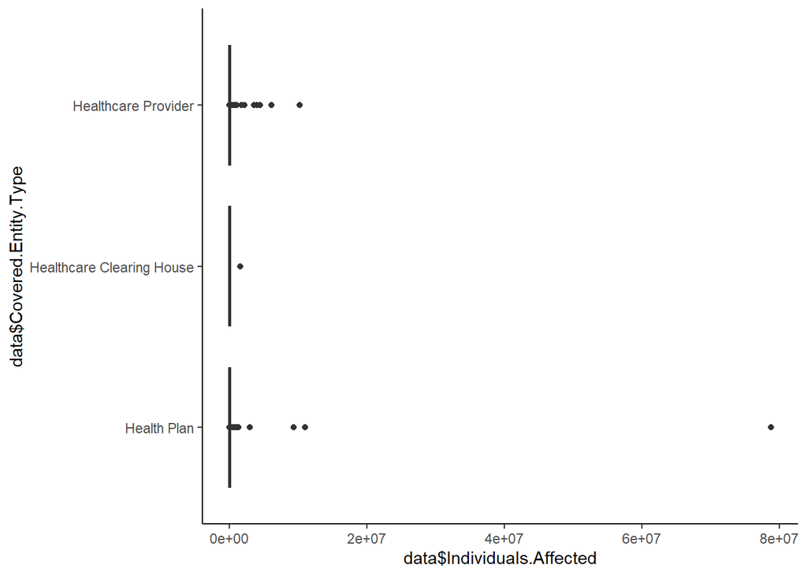

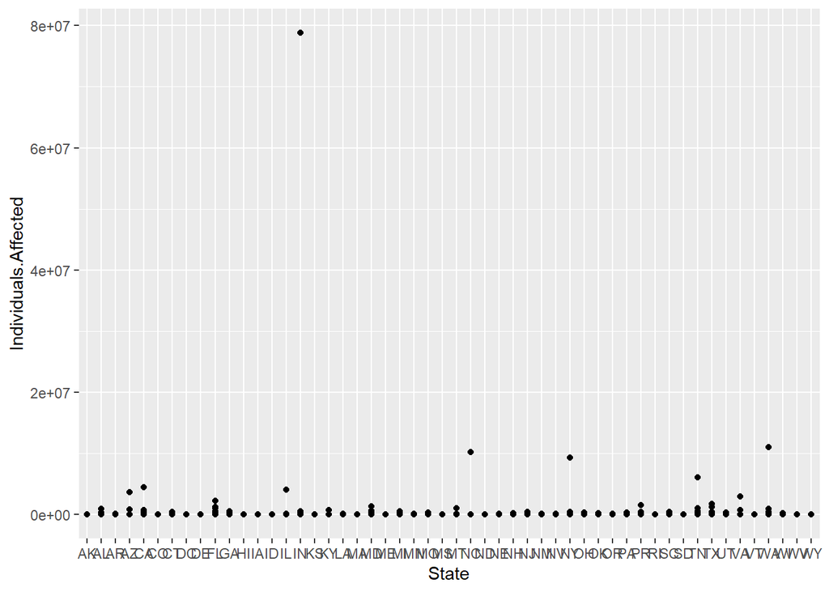

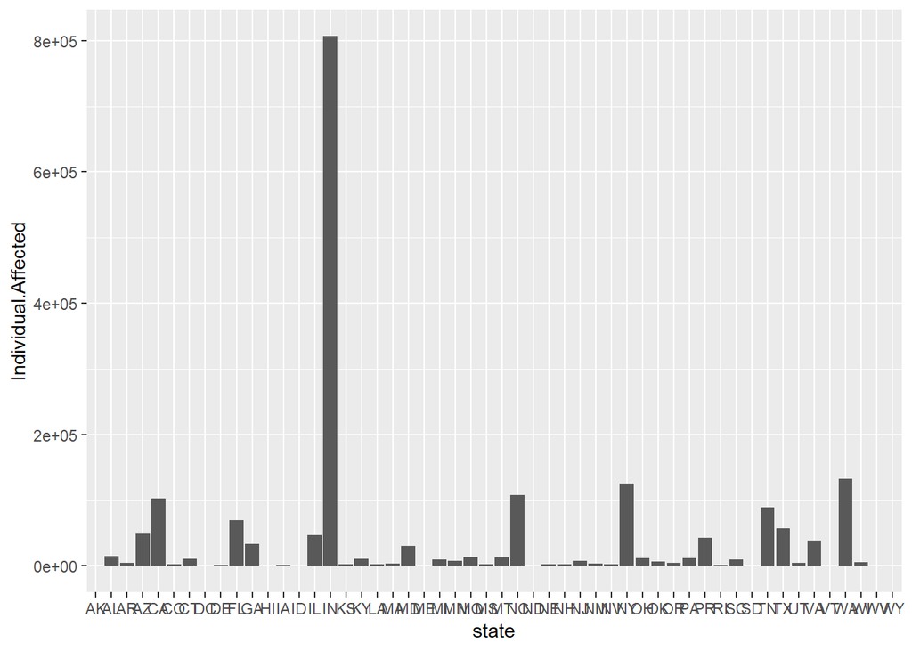

[figure not shown]

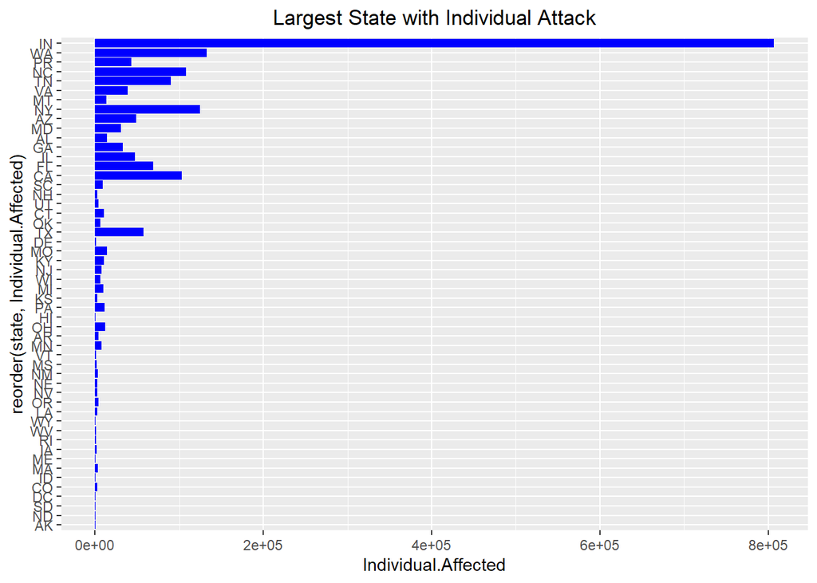

[figure not shown]

```
## [1] 432   7
```

```
## [1] 482   7
```

[figure not shown]

[figure not shown]

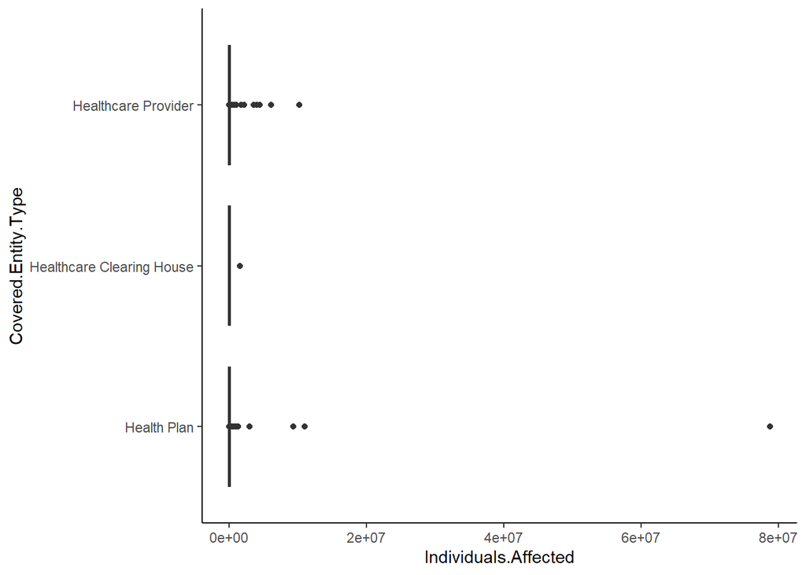

## Conclusion

Pearson’s correlation test revealed that individuals affected by the incidents and years in which the incidents happened are not significantly correlated with a correlation value of 0.001447914 and p-value = 0.9407.